# Reverse Correlation Expt 2 Analysis

## Define Some Important Functions

```r
import_PartData <- function(fileDir){
  #get files in given path
  files <- list.files(path = fileDir, ".csv", full.names = T)

  #marker to create new dataframe
  new <- T

  #do for each file in the directory
  for(file in files){

    #read the file into a dataframe
    data <- read.csv(file, row.names=NULL,stringsAsFactors = F,sep = ',')

    #if this is the first one, create an output dataframe
    if(new){
      outdata <- data
      new <- F
    }
    else{
      #otherwise append it to the existing dataframe
      outdata <- rbind(outdata, data)
    }

  }

  #column name housekeeping
  age <- colnames(outdata)[2]
  colnames(outdata)[2]<- colnames(outdata)[3]
  colnames(outdata)[3]<- age

  #convert to factors and do some more datacleaning
  outdata <- outdata %>% mutate(Answer = as.numeric(replace(Answer, Answer=="NULL", NA)), Repeat. = as.numeric(replace(Repeat., Repeat. != "0", "1")), Target_Type = as.factor(Target_Type), Experiment_Phase = as.factor(Experiment_Phase)) %>% as.data.frame()

  gender <- outdata$Age
  outdata$Age <- outdata$Sex.2.male.3.female.4.other.
  outdata$Sex.2.male.3.female.4.other. <- gender

  remove(gender)

  return(outdata)
}

calculate_imageWise_correlations <- function(fileDir, partData, targetFile){
  #find the .mat files in the given directory.
  files <- list.files(fileDir, full.names = T, pattern = ".mat")

  #get all of the IDs to search the files for
  IDs <- as.character(unique(interaction(partData$Participant_Number, partData$Session_Number, sep="_")))

  #Now load the targets before the loop. readMat is slow, let's do it as few times as possible.
  targets <- readMat(targetFile)

  partData$RelevantImageWiseCorrelation <- NA
  partData$nonRelevantImageWiseCorrelation <- NA

  #iterate through the IDs
  for(ID in IDs){

    #convert ID to numbers for accessing PartData
    ParticipantNumber <- as.numeric(strsplit(ID, "_")[[1]][1])
    SessionNumber <- as.numeric(strsplit(ID, "_")[[1]][2])
    TargetID <- as.numeric(unique(filter(partData, Participant_Number == ParticipantNumber, Session_Number == SessionNumber)$Target_Type))

    #select the relevant file.
    file <- files[grep(paste("/",ID,".mat",sep=''), files)]

    #load the relevant file.
    data <- readMat(file)

    #Discard data that isn't useful
    data <- array(aperm(data$whitenoise,c(2,1,3)), c(2500,2000))

    #load the appropriate target image into memory.
    correctTargetImage <- array(t(targets[[TargetID]]), c(2500))
    #incorrectTargetImage <- array(targets[[-TargetID]], c(2500))

    #now calculate the correlations
    correctCorrelations <- apply(data, 2, cor, y=correctTargetImage)
    #incorrectCorrelations <- apply(data, 2, cor, y=incorrectTargetImage)

    partData$RelevantImageWiseCorrelation[partData$Participant_Number==ParticipantNumber & partData$Session_Number==SessionNumber & partData$Experiment_Phase==" experimental"] <- correctCorrelations[partData$Trial_Number[partData$Participant_Number==ParticipantNumber & partData$Session_Number==SessionNumber & partData$Experiment_Phase==" experimental"]]

  }

  return(partData)
}

calculate_CI_correlations <- function(fileDir, partData, EXPNAME='EXP2'){
  #find the .mat files in the given directory.
  files <- list.files(fileDir, full.names = T, pattern = ".mat")

  #get all of the IDs to search the files for
  IDs <- as.character(unique(interaction(partData$Participant_Number, partData$Session_Number, sep="_")))

  #iterate through the IDs
  for(ID in IDs){

    #convert ID to numbers for accessing PartData
    ParticipantNumber <- as.numeric(strsplit(ID, "_")[[1]][1])
    SessionNumber <- as.numeric(strsplit(ID, "_")[[1]][2])
    TargetID <- as.numeric(unique(filter(partData, Participant_Number == ParticipantNumber, Session_Number == SessionNumber)$Target_Type))

    #select the relevant file.
    file <- files[grep(paste("/",ID,".mat",sep=''), files)]

    #load the relevant file.
    data <- readMat(file)

    #Discard data that isn't useful
    data <- array(aperm(data$whitenoise,c(2,1,3)), c(2500,2000))

    data <- data[,partData$Trial_Number[partData$Participant_Number==ParticipantNumber & partData$Session_Number==SessionNumber & partData$Experiment_Phase==" experimental"]]

    responses <- partData$Response[partData$Participant_Number==ParticipantNumber & partData$Session_Number==SessionNumber & partData$Experiment_Phase==" experimental"]*2 - 1

    data <- t(t(data) * responses)

    if(SessionNumber==1){
      assign(paste0('image', ParticipantNumber), as.matrix(rowSums(data), nrow=1))
    }
    else{
      assign(paste0('image', ParticipantNumber), cbind(get(paste0('image', ParticipantNumber)), as.matrix(rowSums(data), nrow=1)))

      toPNG <- imager::as.cimg(rowSums(get(paste0('image', ParticipantNumber))))

      imager::save.image(toPNG, file = paste0("CIs/",EXPNAME,"/", ParticipantNumber, ".png"))
    }

  }
  for(ID in IDs){

    #convert ID to numbers for accessing PartData
    ParticipantNumber <- as.numeric(strsplit(ID, "_")[[1]][1])
    SessionNumber <- as.numeric(strsplit(ID, "_")[[1]][2])
    TargetID <- as.numeric(unique(filter(partData, Participant_Number == ParticipantNumber, Session_Number == SessionNumber)$Target_Type))

    #select the relevant file.
    file <- files[grep(paste("/",ID,".mat",sep=''), files)]

    #load the relevant file.
    data <- readMat(file)

    #Discard data that isn't useful
    data <- array(aperm(data$whitenoise,c(2,1,3)), c(2500,2000))

    #now calculate the correlations
    CICorrelations <- apply(data, 2, cor, y=rowSums(get(paste0('image', ParticipantNumber))))
    #incorrectCorrelations <- apply(data, 2, cor, y=incorrectTargetImage)

    partData$CIImageWiseCorrelation[partData$Participant_Number==ParticipantNumber & partData$Session_Number==SessionNumber & partData$Experiment_Phase==" experimental"] <- CICorrelations[partData$Trial_Number[partData$Participant_Number==ParticipantNumber & partData$Session_Number==SessionNumber & partData$Experiment_Phase==" experimental"]]

  }
  return(partData)
}

calc_dprime <- function(data){

  pFAs <- summarise(group_by(filter(data, Answer==0), Participant_Number, Experiment_Phase), pFAs=mean(Response))

  pHIT <- summarise(group_by(filter(data, Answer==1), Participant_Number, Experiment_Phase), pHIT=mean(Response))

  output <- merge(pHIT, pFAs)

  output <- mutate(output, pHIT = plyr::mapvalues(pHIT, from = c(0, 1), to = c(1/(80*2), (80*2-1)/(80*2))), pFAs = plyr::mapvalues(pFAs, from = c(0, 1), to = c(1/(80*2), (80*2-1)/(80*2))))

  output <- mutate(output, dprime = qnorm(pHIT) - qnorm(pFAs), ln_beta = (qnorm(pFAs)**2 - qnorm(pHIT)**2)/2)

  return(output)
}
```

## Import the Data and Add the Active v Passive designations.

```r
ParticipantData <- import_PartData("/Volumes/Storage/Experiment_Data/Reverse_Correlation_EXP2/data/")

ParticipantDataCorrelations <- calculate_imageWise_correlations("/Volumes/Storage/Experiment_Data/Reverse_Correlation_EXP2/data/", ParticipantData, "targets4.mat")

ParticipantDataCorrelations <- calculate_CI_correlations("/Volumes/Storage/Experiment_Data/Reverse_Correlation_EXP2/data/", ParticipantDataCorrelations, EXPNAME = 'EXP2')
ExperimentalData <- filter(ParticipantDataCorrelations, Experiment_Phase == " experimental")

TrainingData <- filter(ParticipantDataCorrelations, Experiment_Phase != " experimental")
```

## Training Data Analysis

First let’s use our dprime function to calculate dprime for the hard and easy practice sessions. This will help us get an idea of who is good at this, and who is bad at it. It will also clearly identify who just didn’t get it.

```r
TrainingDprimes <-calc_dprime(TrainingData)
```

Let’s plot the results.

### Dprime

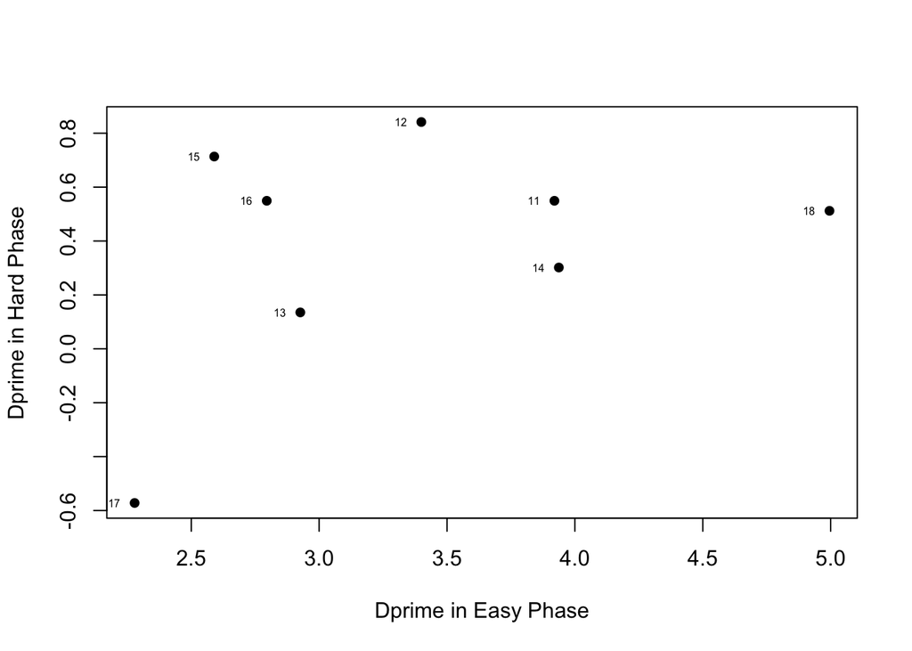

### P(hits)

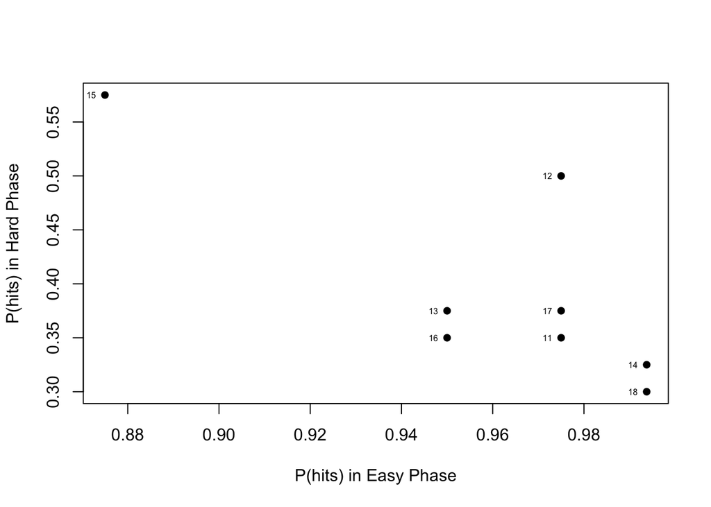

### Ph(false alarms)

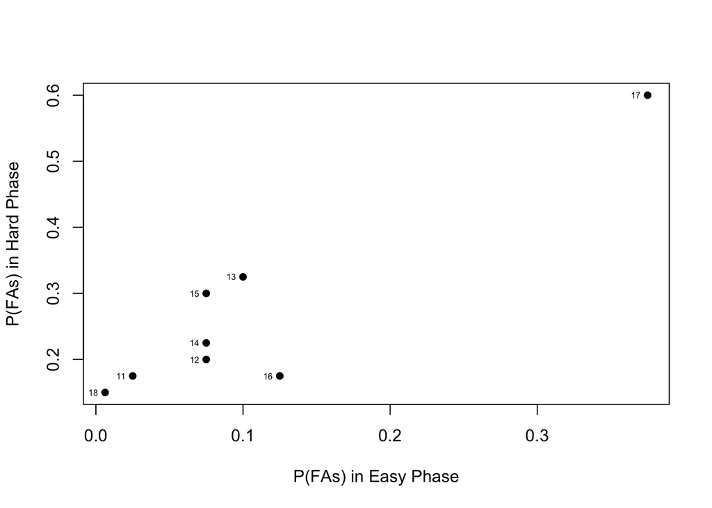

### ln(Beta)

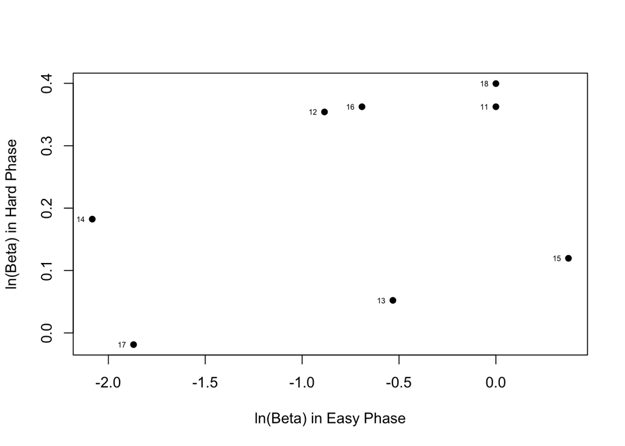

### Coherent training phase summary

```r
Summary_Dprime_data <- summarise(group_by(TrainingDprimes, Experiment_Phase), MeanPhit = mean(pHIT), SEpHit = sd(pHIT)/sqrt(n()),  MeanpFAs = mean(pFAs), SEpFAs = sd(pFAs)/sqrt(n()),  Meandprime = mean(dprime), SEdprime = sd(dprime)/sqrt(n()), Meanln_beta = mean(ln_beta), SEln_beta = sd(ln_beta)/sqrt(n()))


Summary_Dprime_data
```

```
## Source: local data frame [2 x 9]
##
##   Experiment_Phase  MeanPhit     SEpHit  MeanpFAs     SEpFAs Meandprime
##             (fctr)     (dbl)      (dbl)     (dbl)      (dbl)      (dbl)
## 1             easy 0.9609375 0.01360875 0.1070312 0.04056378  3.3552705
## 2             hard 0.3937500 0.03332403 0.2687500 0.05213093  0.3788125
## Variables not shown: SEdprime (dbl), Meanln_beta (dbl), SEln_beta (dbl)
```

### Dprime

```r
#make the bars slightly separated for visual pleasure
dodge <- position_dodge(width = 0.5)

#define the error bar limits
limits <- aes(ymax = Summary_Dprime_data$Meandprime + Summary_Dprime_data$SEdprime,
              ymin = Summary_Dprime_data$Meandprime - Summary_Dprime_data$SEdprime)

#start the plot
p <- ggplot(data =Summary_Dprime_data, aes(x = Experiment_Phase, y = Meandprime))

#now fill the plot
dprimePlot <- p + geom_bar(stat = "identity", position = dodge) +
  geom_errorbar(limits, position = dodge, width = 0.25) +
  theme_bw() +
  theme(panel.grid.major = element_blank(), panel.grid.minor = element_blank())+
  labs(y = "Dprime")+
  ggtitle("Dprime by Experiment Phase") +
  ylim(0,4.5)

#clean up the environment.
remove(p, dodge, limits)
```

### ln_beta

```r
#make the bars slightly separated for visual pleasure
dodge <- position_dodge(width = 0.5)

#define the error bar limits
limits <- aes(ymax = Summary_Dprime_data$Meanln_beta + Summary_Dprime_data$SEln_beta,
              ymin = Summary_Dprime_data$Meanln_beta - Summary_Dprime_data$SEln_beta)

#start the plot
p <- ggplot(data =Summary_Dprime_data, aes(x = Experiment_Phase, y = Meanln_beta))

#now fill the plot
ln_betaPlot <- p + geom_bar(stat = "identity", position = dodge) +
  geom_errorbar(limits, position = dodge, width = 0.25) +
  theme_bw() +
  theme(panel.grid.major = element_blank(), panel.grid.minor = element_blank())+
  labs(y = "Log(Beta)")+
  ggtitle("Log(Beta) by Experiment Phase") +
  ylim(-1.5,1.5)

#clean up the environment.
remove(p, dodge, limits)
```

## Experimental Data Summary

```r
Experimental_Summary_Overall <- summarise(ExperimentalData, meanAge = mean(Age), sdAge = sd(Age), propYes = mean(Response), maxRT = max(RT), minRT = min(RT), sdRT = sd(RT), meanRT = mean(RT), total_trials = n())

 Experimental_Summary_byPRTCPNT <- summarise(group_by(ExperimentalData, Participant_Number), propYes = mean(Response), numYes = sum(Response), maxRT = max(RT), minRT = min(RT), sdRT = sd(RT), meanRT = mean(RT), total_trials = n(), TotalTime = sum(RT)/60)

Experimental_Summary_byTRGT <- summarise(group_by(ExperimentalData, Target_Type), propYes = mean(Response), maxRT = max(RT), minRT = min(RT), sdRT = sd(RT), meanRT = mean(RT), total_trials = n(), total_ptpts = length(unique(Participant_Number)))
```

### Overall summary

```r
Experimental_Summary_Overall
```

```
##    meanAge    sdAge propYes    maxRT       minRT     sdRT    meanRT
## 1 22.91817 2.020147 0.36425 114.6621 0.001487409 1.645965 0.4997131
##   total_trials
## 1        31407
```

It seems as though the overall proportion of yes’s is as expected. Max RT is pretty high. Let’s take a look at the distribution of RTs.

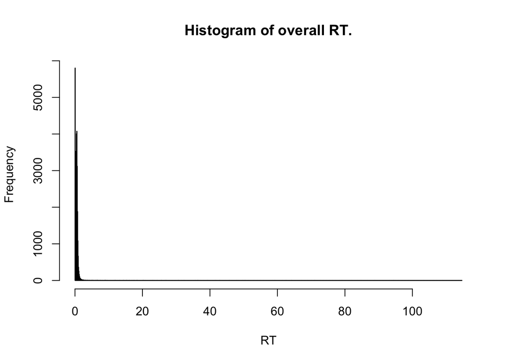

This looks good. Skewed shape as expected. Perhaps we should determine a timing cutoff?

## Analysis of the Image-Wise correlations with CI and Prediction

```r
#tag the images with similar IW correlations to group them later for aggregation
ExperimentalData_CI <- mutate(ExperimentalData, RelIWCorGroup = cut(CIImageWiseCorrelation, quantile(CIImageWiseCorrelation,p = seq(0,1,length.out = 400), na.rm = T)))

#use the RelIWCorGroup above to calculate probYes for each range of IW corrrelation
Experimental_Summary_byRelIWCor_CI <- summarise(group_by(ExperimentalData_CI, RelIWCorGroup), IWcor = mean(CIImageWiseCorrelation), pYes = mean(Response))
```

Now let’s go ahead and do the scatter plots so get an idea of the relationships before we do the formal stats. Here we can also identify outliers.

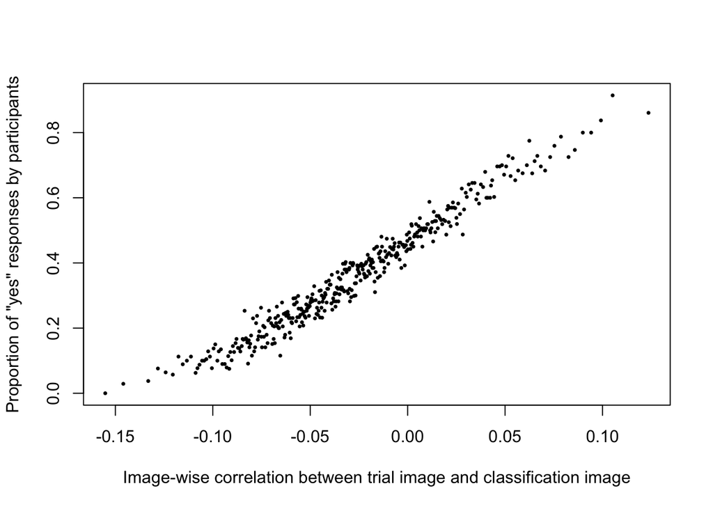

```r
with(filter(Experimental_Summary_byRelIWCor_CI), plot(IWcor, pYes, pch=16, cex=0.5, xlab = "Image-wise correlation between trial image and classification image", ylab = "Proportion of \"yes\" responses by participants"))
```

Now we can go ahead and calculate the correlations here.

```r
print("Correlation:")
```

```
## [1] "Correlation:"
```

```r
with(Experimental_Summary_byRelIWCor_CI, cor.test(pYes,IWcor))
```

```
##
##  Pearson's product-moment correlation
##
## data:  pYes and IWcor
## t = 99.262, df = 398, p-value < 2.2e-16
## alternative hypothesis: true correlation is not equal to 0
## 95 percent confidence interval:
##  0.9761830 0.9838679
## sample estimates:
##       cor
## 0.9803948
```

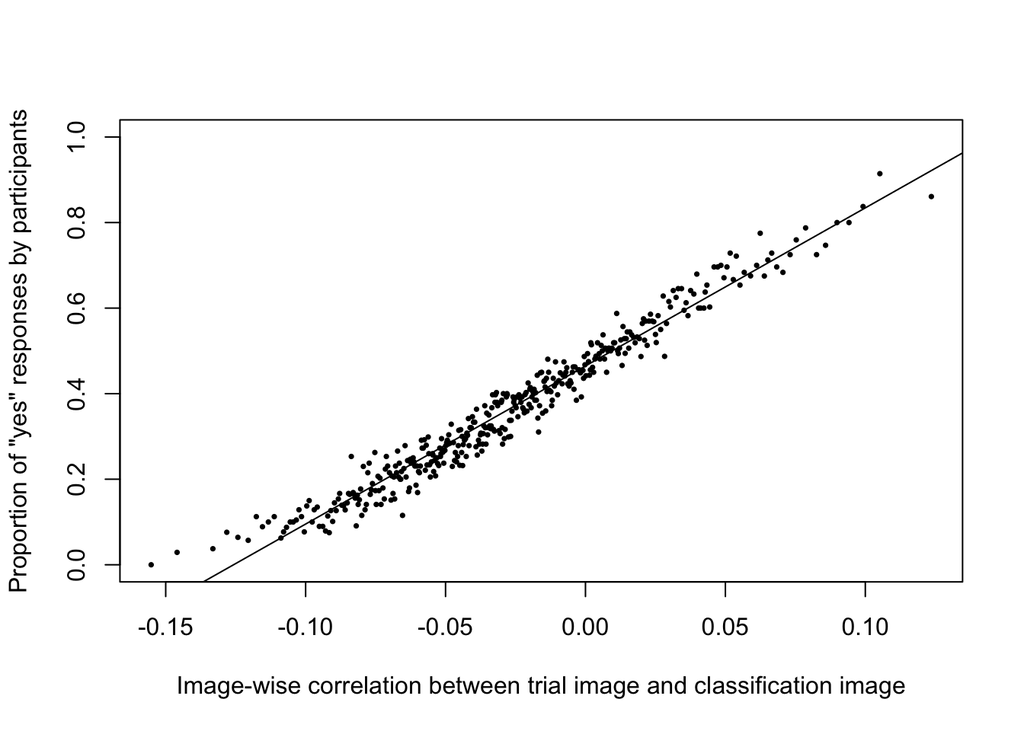

## Analysis of the Image-Wise correlations and Prediction

First step: aggregate likelihood of image being chosen as a “yes” given its correlation with the target.

```r
#tag the images with similar IW correlations to group them later for aggregation
ExperimentalData <- mutate(ExperimentalData, RelIWCorGroup = cut(RelevantImageWiseCorrelation, quantile(RelevantImageWiseCorrelation,p = seq(0,1,length.out = 400), na.rm = T)))

#use the RelIWCorGroup above to calculate probYes for each range of IW corrrelation
Experimental_Summary_byRelIWCor <- summarise(group_by(ExperimentalData, RelIWCorGroup), IWcor = mean(RelevantImageWiseCorrelation), pYes = mean(Response))
```

Now let’s go ahead and do the scatter plots so get an idea of the relationships before we do the formal stats. Here we can also identify outliers.

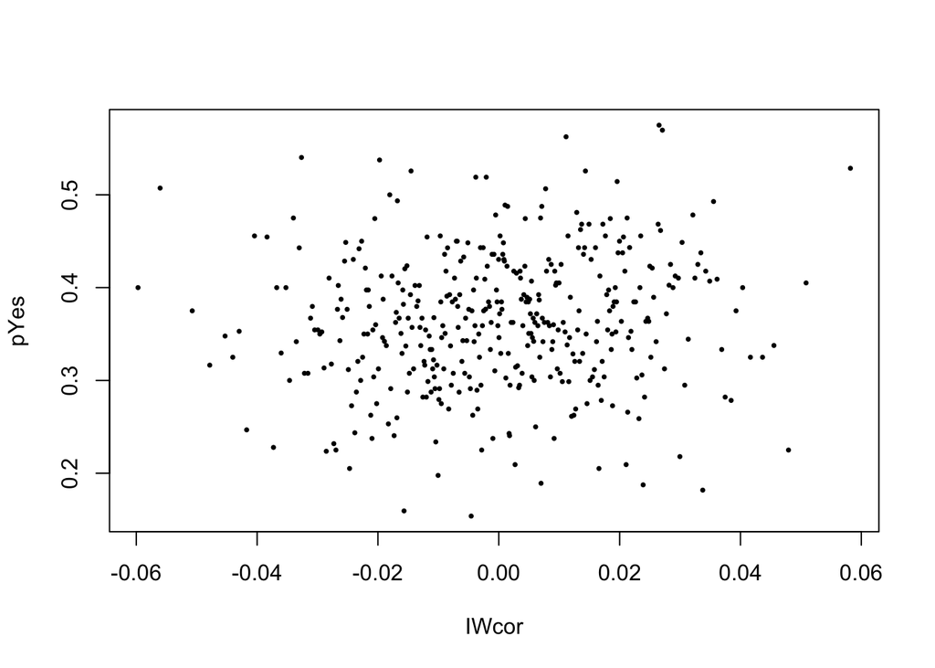

```r
with(filter(Experimental_Summary_byRelIWCor), plot(IWcor, pYes, pch=16, cex=0.5))
```

```r
print("Correlation:")
```

```
## [1] "Correlation:"
```

```r
with(filter(Experimental_Summary_byRelIWCor, !is.na(RelIWCorGroup)), cor.test(pYes,IWcor))
```

```
##
##  Pearson's product-moment correlation
##
## data:  pYes and IWcor
## t = 2.0384, df = 397, p-value = 0.04217
## alternative hypothesis: true correlation is not equal to 0
## 95 percent confidence interval:
##  0.003635127 0.197970070
## sample estimates:
##       cor
## 0.1017735
```

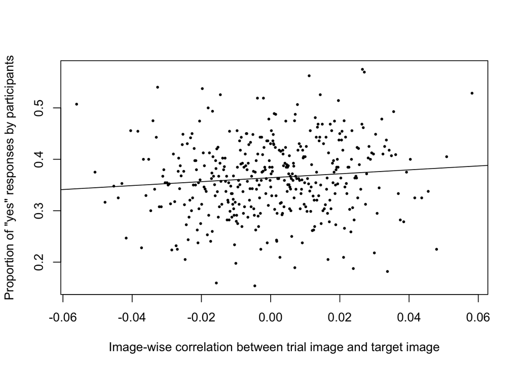